# PSY 8712 Week 8 Project

Sarah Nakamoto

## **Reproducible Image and Online Resources:**

An image of this project as of *2024-03-18* can be accessed by [clicking this link](https://mybinder.org/v2/gh/nakam087/psy8712-week8/HEAD?urlpath=rstudio). An interactive web app is available by [clicking this link instead](https://chiems.shinyapps.io/shiny_week8/).

## **Script Settings and Resources**

```r
setwd(dirname(rstudioapi::getActiveDocumentContext()$path))
library(tidyverse)
library(shiny)
```

## **Data Import and Cleaning**

Here I have cleaned the week3.csv similarly to the previous week relabeled the columns, recoded gender as a factor, and reverse coded q5. Then, I created new variables displaying means of q1:q6 and q8:q10.

```r
week8_tbl <- read_csv("../data/week3.csv")%>%
  mutate(timeStart=ymd_hms(timeStart))%>%
  mutate(gender=recode_factor(gender, "M"="Male","F"="Female"))%>%
  mutate(q5=6-q5)%>%
  rowwise()%>%
  mutate(q1q6_mean=mean(c(q1,q2,q3,q4,q5,q6)))%>%
  mutate(q8q10_mean=mean(c(q8,q9,q10)))
```

## **Visualization**

I selected question 1 through question 6 of week8_tbl, and changed the yaml header to make it so that when displayed, the data was paginated. For the graph, I made a scatterplot and specified the line to be lm method and the color purple, making the standard error band visible.

| q1 | q2 | q3 | q4 | q5 | q6 |
| --- | --- | --- | --- | --- | --- |
| 5 | 4 | 4 | 1 | 2 | 1 |
| 2 | 4 | 3 | 1 | 3 | 1 |
| 5 | 5 | 2 | 1 | 5 | 1 |
| 4 | 3 | 4 | 2 | 4 | 1 |
| 3 | 1 | 3 | 5 | 2 | 1 |
| 4 | 3 | 2 | 3 | 3 | 1 |
| 2 | 4 | 1 | 3 | 1 | 1 |
| 4 | 2 | 5 | 1 | 1 | 1 |
| 2 | 5 | 3 | 4 | 2 | 1 |
| 3 | 4 | 2 | 4 | 5 | 1 |

[output cut: 39 more lines]

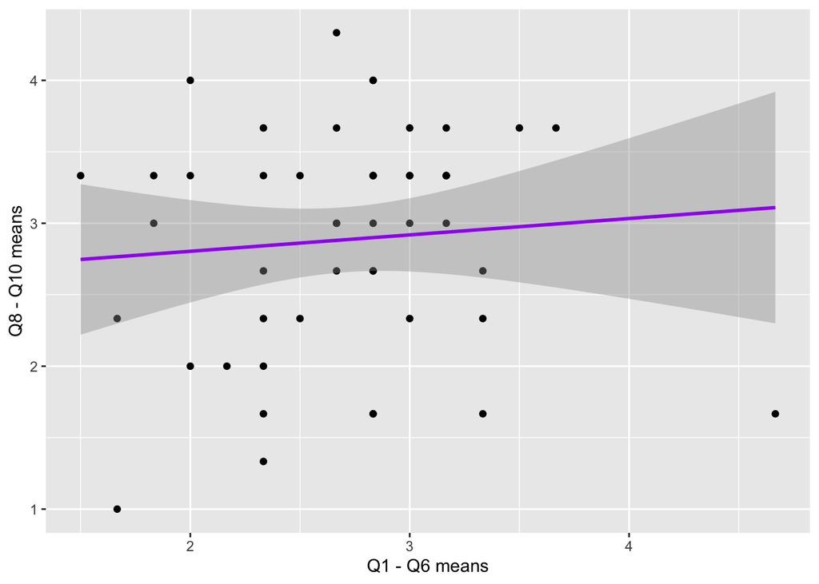

## **Analysis**

I had to write the cor.test code without using a pipe because it was not a tidyverse function. I also used a combination of the str_remove and round functions to make sure the decimal did not have a zero in the ones place (“^0”) and was rounded to the hundredths place.

```
##
##  Pearson's product-moment correlation
##
## data:  week8_tbl$q1q6_mean and week8_tbl$q8q10_mean
## t = 0.58309, df = 47, p-value = 0.5626
## alternative hypothesis: true correlation is not equal to 0
## 95 percent confidence interval:
##  -0.2012466  0.3574248
## sample estimates:
##        cor
## 0.08474575
```

I observed a correlation of .08. Because the p value (0.5626235) is greater than alpha=0.05, we fail to reject the null hypothesis and thus the true correlation is not significantly different from zero. Thus, answers from q1-q6 are not significantly correlated with answers from q8-q10.

## **Data Export**

I used select to choose the important elements from week8_tbl, and then used saveRDS to save the file in the shiny folder.

```r
week8_tbl %>%
  select(timeEnd,gender,q1q6_mean,q8q10_mean) %>%
  saveRDS("../shiny_week8/data.rds")
```